# Final analysis

Sarina Singh Khaira

02/11/2021

## Economic analysis (Global Competitiveness Index)

#### How have global competitiveness rankings changed over time?

For the purposes of this exploration I will include the 10 top ranking countries for GCI.

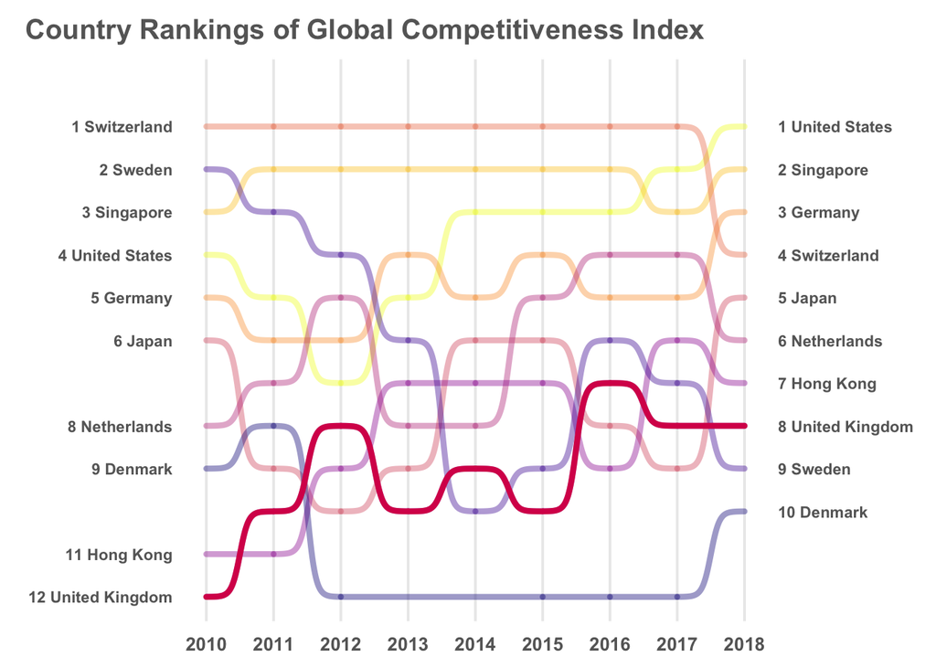

#### Do the top performing countries in terms of global competitiveness have different areas of strength and weaknesses within the calculation of the index?

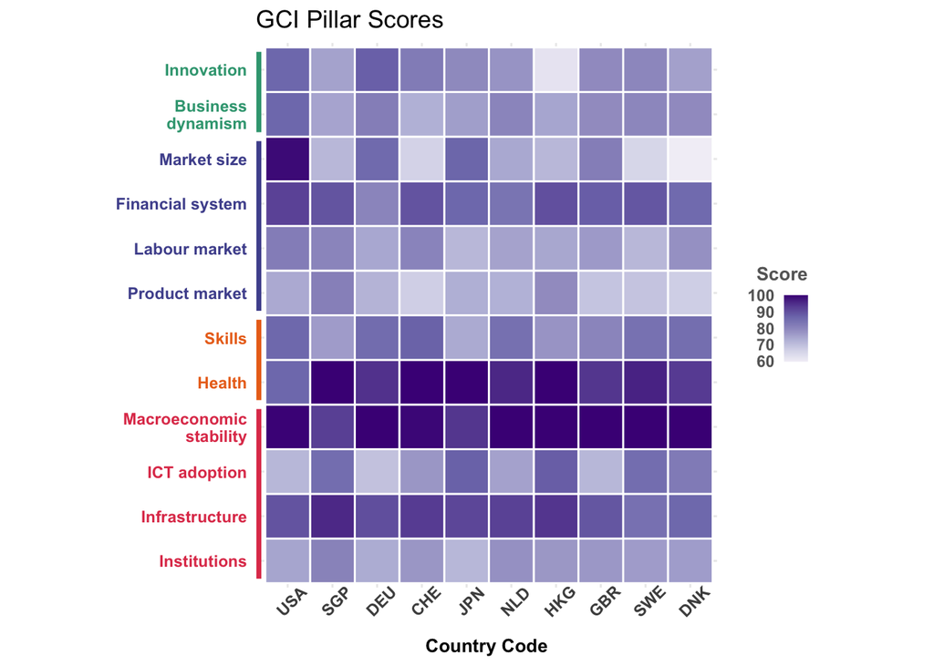

Generally speaking countries tend to have high scores for health, macroeconomic stability, infrastucture and financial systems. When looking at the UK in particular it seems to be lagging behind other nations in ICT adoption and product market. The GCI does not contain a weighting towards environmental sustainability or social equity - both of which have been highlighted by the WEF as characteristics that will aid economies to continue to grow into the future.

I will now look at each of these in turn, before considering the global sustainability index which takes into account a wide variety of indicators. The countries selected for the following comparisons feature the top 4 countries in both global competitiveness and the top4 for global sustainable competitiveness, and the UK.

| GCI | GSCI |
| --- | --- |
| USA | Sweden |
| Singapore | Denmark |
| Germany | Iceland |
| Switzerland | Finland |

## Social equity analysis

I have chosen to look at the gender gap index (a proxy for gender inequality) and the Gini index which is a proxy for the distribution of wealth within society. I have also chosen to look at the ‘World Happiness Index’ which comes from a global survey.

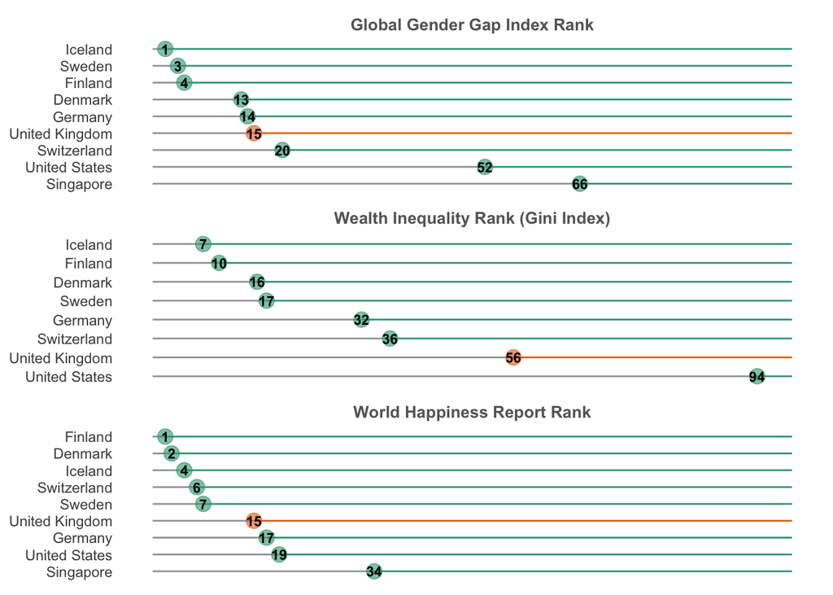

## Environmental analysis

The metrics used here are the consumption of carbon dioxide per capita, the natural capital score as derived from the global sustainable competitiveness index as well as the proportion of renewable energy consumption per country.

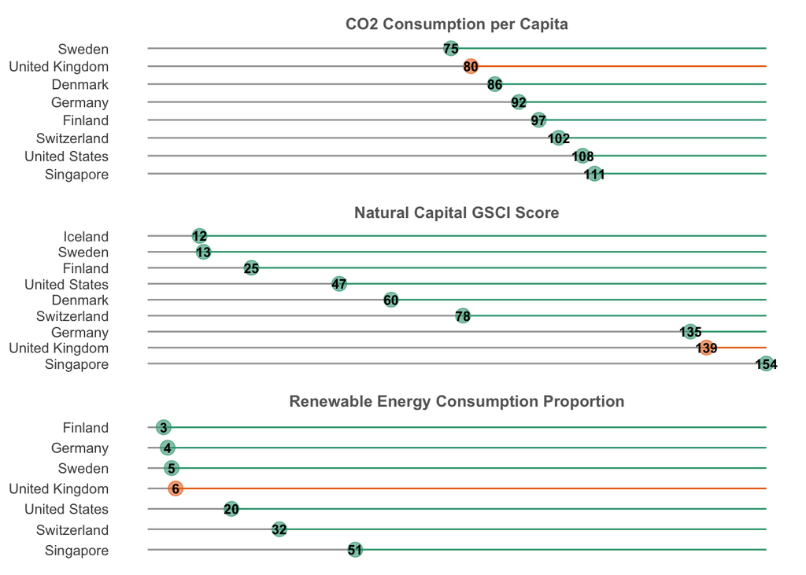

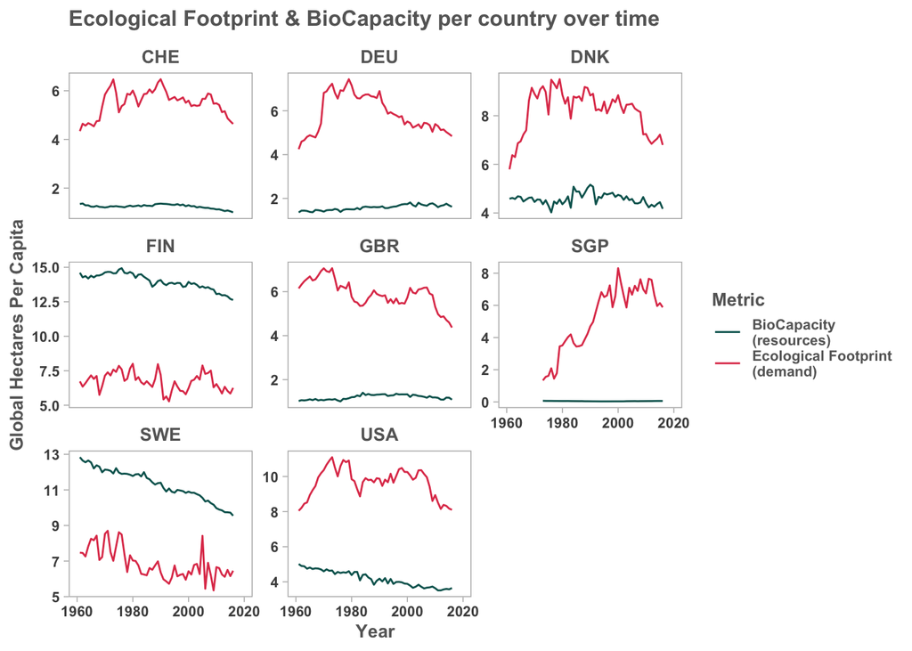

I have also chosen to look at the BioCapacity and Ecological footprint and how this has changed over the past half century. BioCapacity indicates the carbon stores that a country may have - essentially it represents a carbon sink. The Ecological footprint represents the carbon consumption. The goal is always to have a higher BioCapacity than Ecological footprint. Out of the top countries only 2 achieve this - Finland and Sweden - though in both cases the BioCapacity seems to be declining. The UK shows a similar pattern to Switzerland, USA, Germany and Denmark with a seemingly narrowing gap - a sign of positive change. It is important to note that every plot has a different scale on the y axis. Singapore however demonstrates a worrying trend with its BioCapacity incredibly low and stagnant, with a rapidly increasing Ecological footprint.

# Relationships between metrics

I have produced a correlation matrix to see what relationships may exist between any two indicators/indexes used in this analysis.

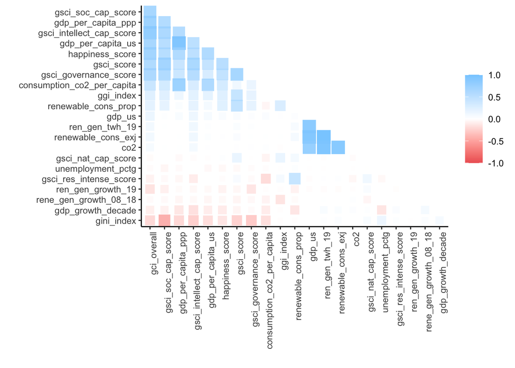

## Relationship between GDP and GSCI pillars

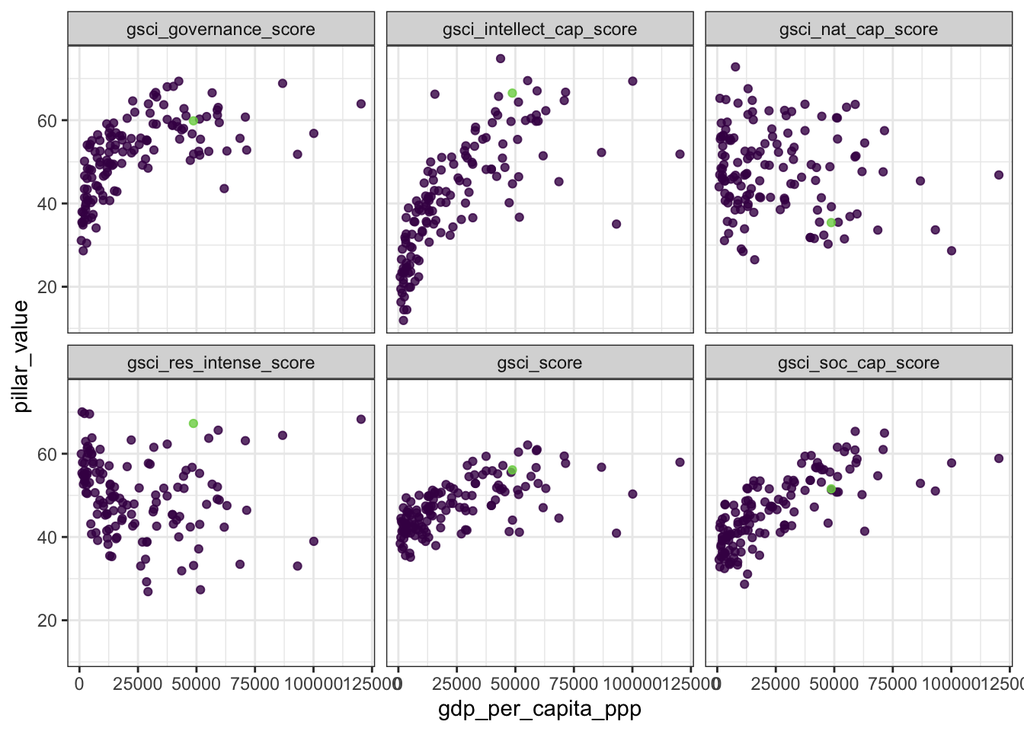

The pattern between GDP and the individual pillar scores for the GSCI seem to be most noticeable in the intellectual capital score and governance score. Natural capital and resource intensity do not seem to vary with GDP indicating that these aspects may level out developing nations with developed nations. I decided not to include GDP into the clustering analysis, but will just use the GSCI Index pillars.

# Cluster Analysis

## Data preparation for clustering

```
##               gsci_score       gsci_nat_cap_score   gsci_res_intense_score
##                        2                        2                        2
##       gsci_soc_cap_score gsci_intellect_cap_score    gsci_governance_score
##                        2                        2                        2
```

## Choosing K and validating clustering

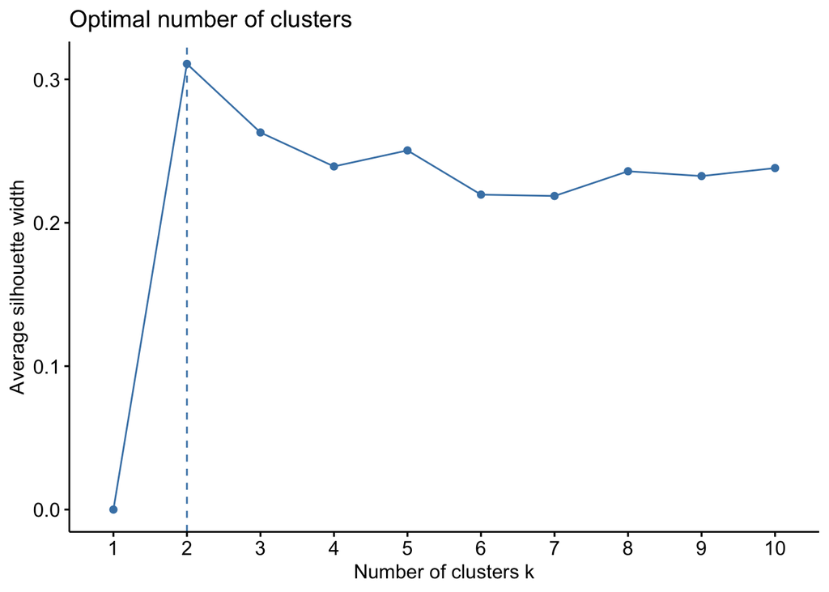

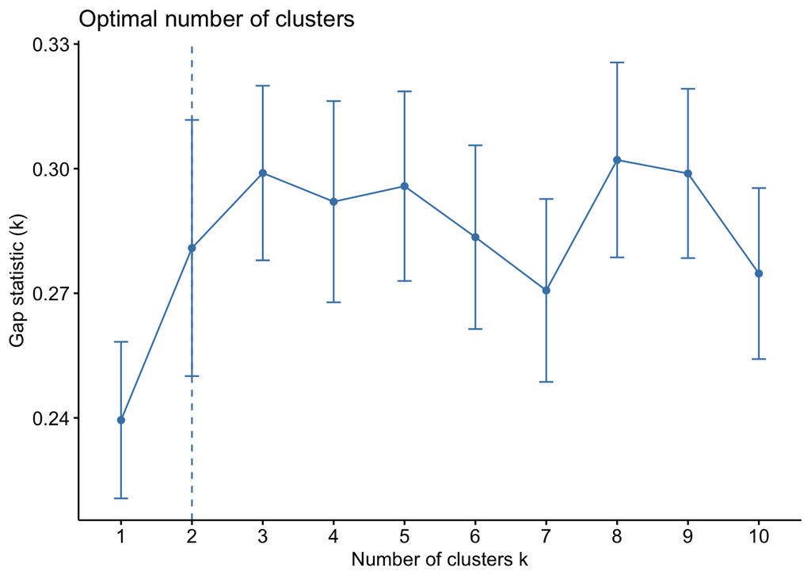

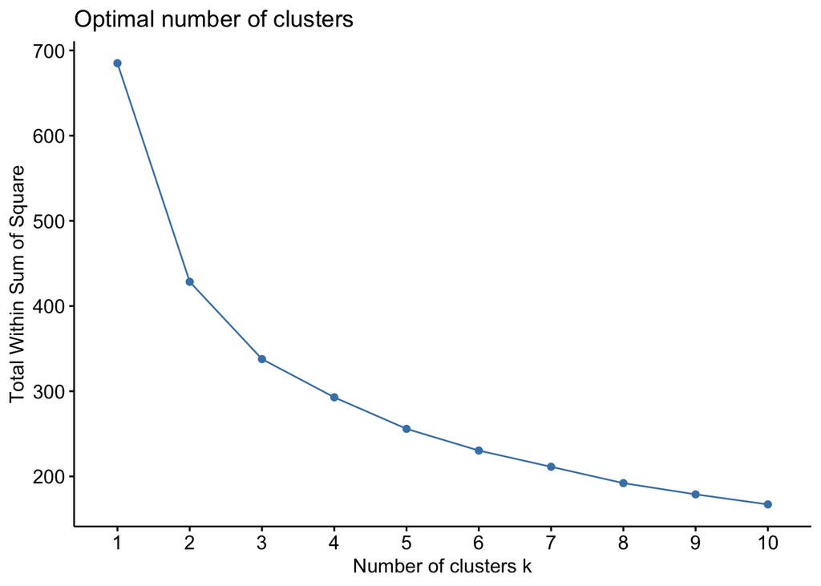

Select 2 as the optimal number of clusters

## Perform Kmeans clustering

### Model output

```
## # A tibble: 2 x 8
##   gsci_nat_cap_score gsci_res_intense_sc… gsci_soc_cap_sco… gsci_intellect_cap_…
##                <dbl>                <dbl>             <dbl>                <dbl>
## 1              0.130                0.352            -0.812               -0.816
## 2             -0.119               -0.323             0.745                0.748
## # … with 4 more variables: gsci_governance_score <dbl>, size <int>,
## #   withinss <dbl>, cluster <fct>
```

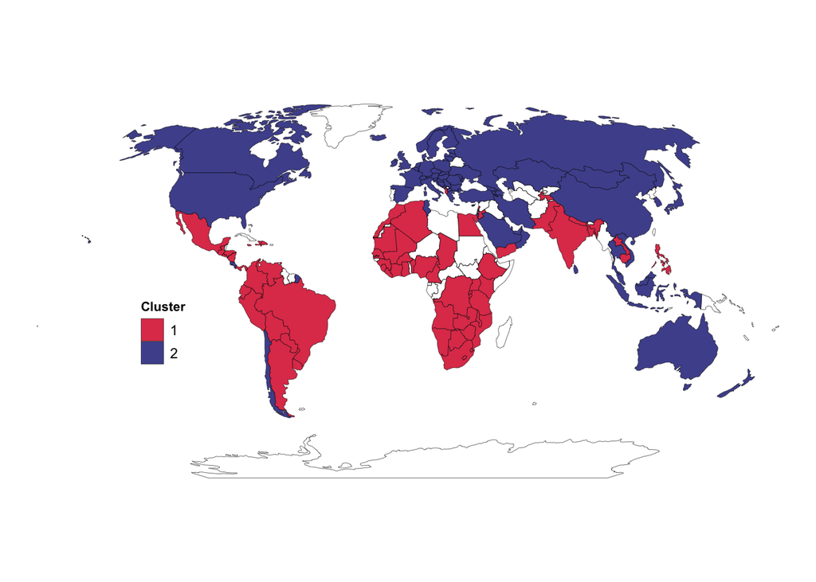

# Pillar Scores for each cluster

The two clusters of countries are as such:

Cluster 1 - low governance, intellectual capital and social capital scores.

Cluster 2 - higher governance, intellectual capital and social capital.

Natural capital and resource intensity showed little difference between the two clusters - indicating that there is less of a global pattern here, and that they are on a case by case basis.

# Conclusions & Key insights

- According to the WEF, the UK ranks as the 8th most competitive economy in the world
- Falls to 15th when sustainability & social equity are considered (GSCI Ranking)
- Social capital requires improvement - including gender gap & distribution of wealth
- The UK is making progress towards becoming more environmentally sustainable which should improve its natural capital rankings over time, it is currently in 139th place.
- Sweden, Finland, Denmark & Switzerland appear to be on the trajectory of productive, low- carbon & inclusive economies